# BM_HW5

Yujing FU

2024-12-08

## a) Provide descriptive statistics for all variables of interest (continuous and categorical)

```r
library(faraway)
library(janitor)

state_data =
  as.data.frame(state.x77) |>
  janitor::clean_names()
summary(state_data)
```

```
##    population        income       illiteracy       life_exp
##  Min.   :  365   Min.   :3098   Min.   :0.500   Min.   :67.96
##  1st Qu.: 1080   1st Qu.:3993   1st Qu.:0.625   1st Qu.:70.12
##  Median : 2838   Median :4519   Median :0.950   Median :70.67
##  Mean   : 4246   Mean   :4436   Mean   :1.170   Mean   :70.88
##  3rd Qu.: 4968   3rd Qu.:4814   3rd Qu.:1.575   3rd Qu.:71.89
##  Max.   :21198   Max.   :6315   Max.   :2.800   Max.   :73.60
##      murder          hs_grad          frost             area
##  Min.   : 1.400   Min.   :37.80   Min.   :  0.00   Min.   :  1049
##  1st Qu.: 4.350   1st Qu.:48.05   1st Qu.: 66.25   1st Qu.: 36985
##  Median : 6.850   Median :53.25   Median :114.50   Median : 54277
##  Mean   : 7.378   Mean   :53.11   Mean   :104.46   Mean   : 70736
##  3rd Qu.:10.675   3rd Qu.:59.15   3rd Qu.:139.75   3rd Qu.: 81163
##  Max.   :15.100   Max.   :67.30   Max.   :188.00   Max.   :566432
```

## b) Examine exploratory plots, e.g., scatter plots, histograms, box-plots to get a sense of the data and possible variable transformations. If you find a transformation to be necessary or recommended, perform the transformation and use it through the rest of the problem.

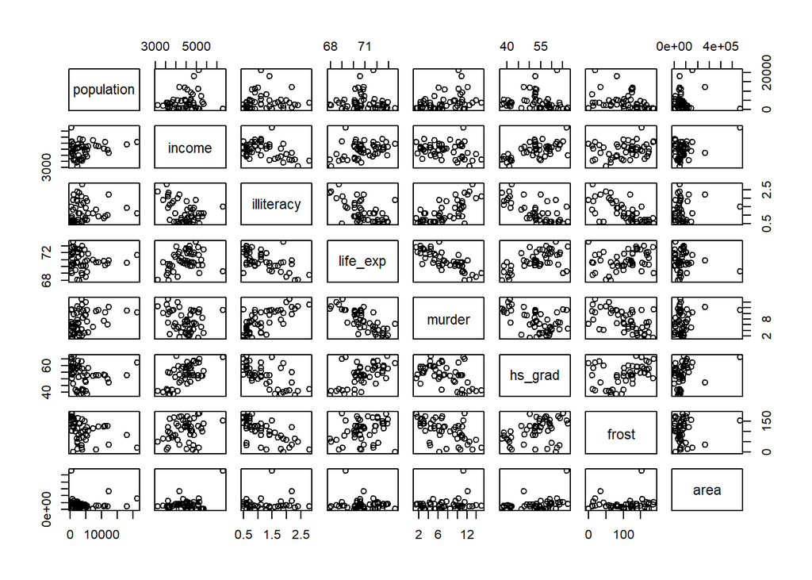

```r
library(ggplot2)

# scatter plots
pairs(state_data)
```

```r
# b) Exploratory Data Analysis and Visualization
# Create a correlation matrix
cor_matrix <- cor(state_data)
cor_matrix
```

```
##             population     income  illiteracy    life_exp     murder
## population  1.00000000  0.2082276  0.10762237 -0.06805195  0.3436428
## income      0.20822756  1.0000000 -0.43707519  0.34025534 -0.2300776
## illiteracy  0.10762237 -0.4370752  1.00000000 -0.58847793  0.7029752
## life_exp   -0.06805195  0.3402553 -0.58847793  1.00000000 -0.7808458
## murder      0.34364275 -0.2300776  0.70297520 -0.78084575  1.0000000
## hs_grad    -0.09848975  0.6199323 -0.65718861  0.58221620 -0.4879710
## frost      -0.33215245  0.2262822 -0.67194697  0.26206801 -0.5388834
## area        0.02254384  0.3633154  0.07726113 -0.10733194  0.2283902
##                hs_grad      frost        area
## population -0.09848975 -0.3321525  0.02254384
## income      0.61993232  0.2262822  0.36331544
## illiteracy -0.65718861 -0.6719470  0.07726113
## life_exp    0.58221620  0.2620680 -0.10733194
## murder     -0.48797102 -0.5388834  0.22839021
## hs_grad     1.00000000  0.3667797  0.33354187
## frost       0.36677970  1.0000000  0.05922910
## area        0.33354187  0.0592291  1.00000000
```

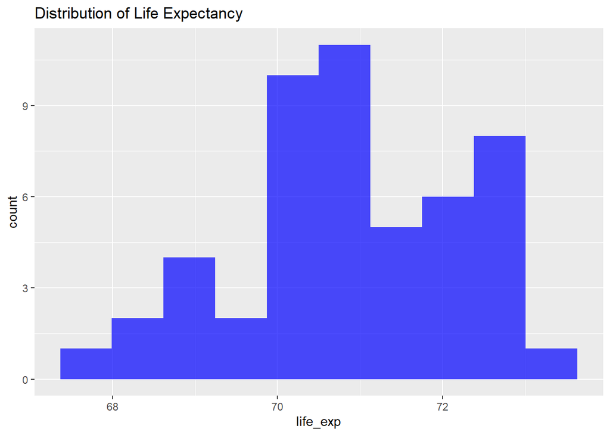

```r
# Create plots for distributions and relationships
# Histogram of Life Expectancy
p1 <- ggplot(state_data, aes(x = life_exp)) +
  geom_histogram(bins = 10, fill = "blue", alpha = 0.7) +
  labs(title = "Distribution of Life Expectancy")
p1
```

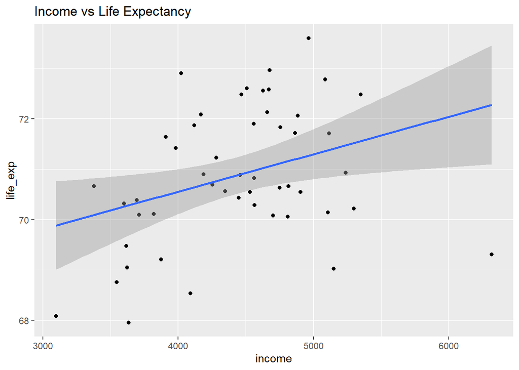

```r
# Scatter plots of key predictors vs Life Expectancy
p2 <- ggplot(state_data, aes(x = income, y = life_exp)) +
  geom_point() +
  geom_smooth(method = "lm") +
  labs(title = "Income vs Life Expectancy")
p2
```

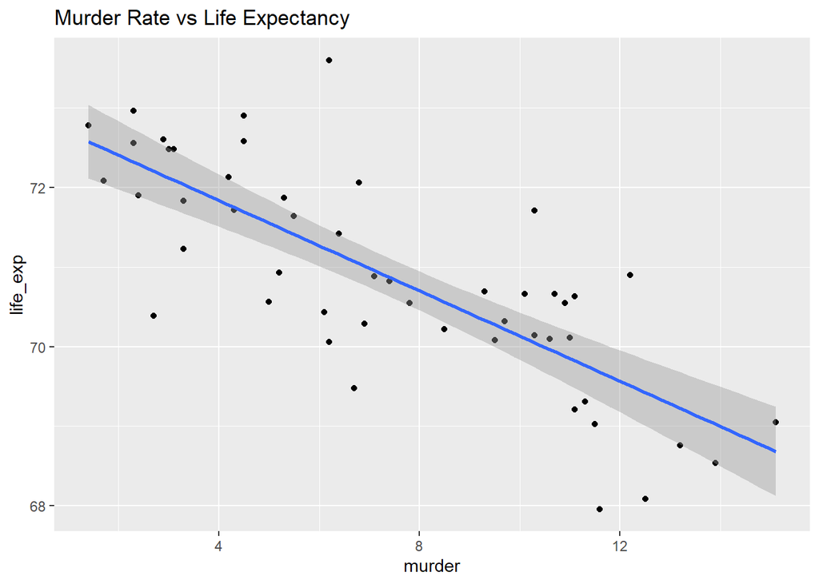

```r
p3 <- ggplot(state_data, aes(x = murder, y = life_exp)) +
  geom_point() +
  geom_smooth(method = "lm") +
  labs(title = "Murder Rate vs Life Expectancy")
p3
```

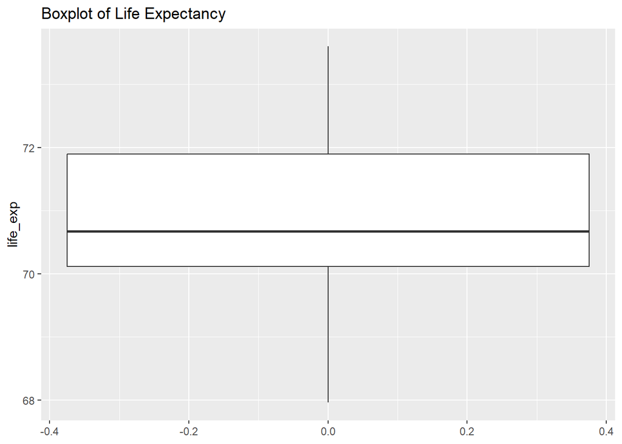

```r
# Boxplot of Life Expectancy
p4 <- ggplot(state_data, aes(y = life_exp)) +
  geom_boxplot() +
  labs(title = "Boxplot of Life Expectancy")
p4
```

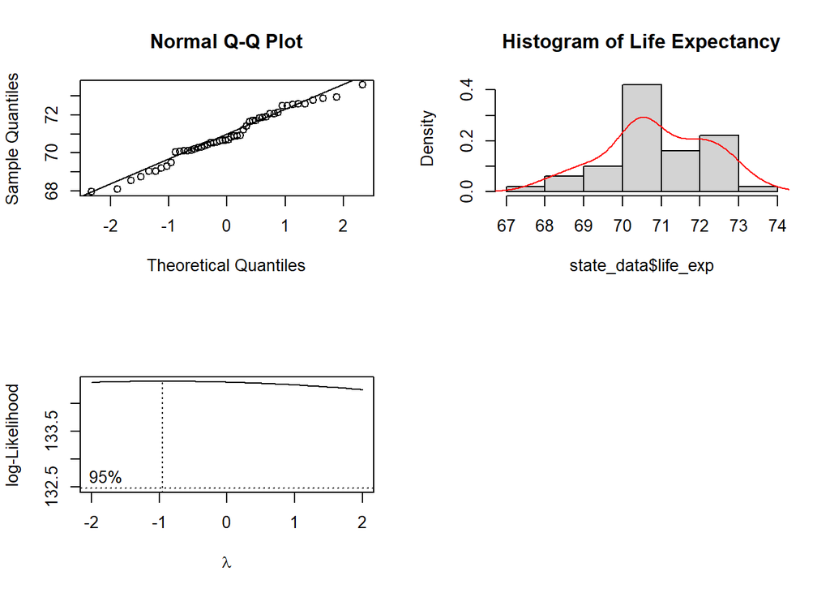

```r
library(MASS)
library(car)
# Check normality and potential transformations for life expectancy
# 1. Normality Check
par(mfrow=c(2,2))
# Q-Q Plot
qqnorm(state_data$life_exp)
qqline(state_data$life_exp)

# Histogram with density curve
hist(state_data$life_exp, prob=TRUE, main="Histogram of Life Expectancy")
lines(density(state_data$life_exp), col="red")

# Box-Cox transformation to find optimal lambda
boxcox_result <- boxcox(life_exp ~ ., data = state_data)
```

The best lamda is -1, therefore we tranformed the `life_exp` in inverse method.

```r
state_data$transformed_life_exp <- 1 / state_data$life_exp
```

## c) Use automatic procedures to find a ‘best subset’ of the full model.

```r
# c) Automatic Subset Selection Procedures
library(leaps)
library(dplyr)

# Prepare the data
X <- state_data %>% select(-life_exp, -transformed_life_exp)  # Fix the parentheses here
y <- state_data$transformed_life_exp

# Backward Elimination
full_model <- lm(transformed_life_exp ~ ., data = state_data %>% select(-life_exp))

backward_model <- step(full_model, direction = "backward")
```

```
## Start:  AIC=-874.47
## transformed_life_exp ~ population + income + illiteracy + murder +
##     hs_grad + frost + area
##
##              Df  Sum of Sq        RSS     AIC
## - illiteracy  1 0.0000e+00 9.2131e-07 -876.47
## - area        1 0.0000e+00 9.2131e-07 -876.47
## - income      1 2.5000e-10 9.2156e-07 -876.46
## <none>                     9.2131e-07 -874.47
## - frost       1 7.4100e-08 9.9541e-07 -872.61
## - population  1 7.5180e-08 9.9649e-07 -872.55
## - hs_grad     1 9.3970e-08 1.0153e-06 -871.62
## - murder      1 9.1741e-07 1.8387e-06 -841.92
##
## Step:  AIC=-876.47
## transformed_life_exp ~ population + income + murder + hs_grad +
##     frost + area
##
##              Df  Sum of Sq        RSS     AIC
## - area        1 0.0000e+00 9.2131e-07 -878.47
## - income      1 2.6000e-10 9.2157e-07 -878.46
## <none>                     9.2131e-07 -876.47
## - population  1 8.0840e-08 1.0022e-06 -874.27
## - frost       1 1.1323e-07 1.0345e-06 -872.68
## - hs_grad     1 1.2456e-07 1.0459e-06 -872.13
## - murder      1 1.0322e-06 1.9535e-06 -840.90
##
## Step:  AIC=-878.47
## transformed_life_exp ~ population + income + murder + hs_grad +
##     frost
##
##              Df  Sum of Sq        RSS     AIC
## - income      1 2.8000e-10 9.2159e-07 -880.46
## <none>                     9.2131e-07 -878.47
## - population  1 8.3240e-08 1.0046e-06 -876.15
## - frost       1 1.1524e-07 1.0366e-06 -874.58
## - hs_grad     1 1.4062e-07 1.0619e-06 -873.37
## - murder      1 1.3878e-06 2.3091e-06 -834.53
##
## Step:  AIC=-880.46
## transformed_life_exp ~ population + murder + hs_grad + frost
##
##              Df  Sum of Sq        RSS     AIC
## <none>                     9.2159e-07 -880.46
## - population  1 9.0960e-08 1.0125e-06 -877.75
## - frost       1 1.1857e-07 1.0402e-06 -876.41
## - hs_grad     1 2.0505e-07 1.1266e-06 -872.41
## - murder      1 1.3910e-06 2.3126e-06 -836.46
```

```r
# Stepwise Regression
stepwise_model <- step(full_model, direction = "both")
```

```
## Start:  AIC=-874.47
## transformed_life_exp ~ population + income + illiteracy + murder +
##     hs_grad + frost + area
##
##              Df  Sum of Sq        RSS     AIC
## - illiteracy  1 0.0000e+00 9.2131e-07 -876.47
## - area        1 0.0000e+00 9.2131e-07 -876.47
## - income      1 2.5000e-10 9.2156e-07 -876.46
## <none>                     9.2131e-07 -874.47
## - frost       1 7.4100e-08 9.9541e-07 -872.61
## - population  1 7.5180e-08 9.9649e-07 -872.55
## - hs_grad     1 9.3970e-08 1.0153e-06 -871.62
## - murder      1 9.1741e-07 1.8387e-06 -841.92
##
## Step:  AIC=-876.47
## transformed_life_exp ~ population + income + murder + hs_grad +
##     frost + area
##
##              Df  Sum of Sq        RSS     AIC
## - area        1 0.0000e+00 9.2131e-07 -878.47
## - income      1 2.6000e-10 9.2157e-07 -878.46
## <none>                     9.2131e-07 -876.47
## + illiteracy  1 0.0000e+00 9.2131e-07 -874.47
## - population  1 8.0840e-08 1.0022e-06 -874.27
## - frost       1 1.1323e-07 1.0345e-06 -872.68
## - hs_grad     1 1.2456e-07 1.0459e-06 -872.13
## - murder      1 1.0322e-06 1.9535e-06 -840.90
##
## Step:  AIC=-878.47
## transformed_life_exp ~ population + income + murder + hs_grad +
##     frost
##
##              Df  Sum of Sq        RSS     AIC
## - income      1 2.8000e-10 9.2159e-07 -880.46
## <none>                     9.2131e-07 -878.47
## + area        1 0.0000e+00 9.2131e-07 -876.47
## + illiteracy  1 0.0000e+00 9.2131e-07 -876.47
## - population  1 8.3240e-08 1.0046e-06 -876.15
## - frost       1 1.1524e-07 1.0366e-06 -874.58
## - hs_grad     1 1.4062e-07 1.0619e-06 -873.37
## - murder      1 1.3878e-06 2.3091e-06 -834.53
##
## Step:  AIC=-880.46
## transformed_life_exp ~ population + murder + hs_grad + frost
##
##              Df  Sum of Sq        RSS     AIC
## <none>                     9.2159e-07 -880.46
## + income      1 2.8000e-10 9.2131e-07 -878.47
## + area        1 2.0000e-11 9.2157e-07 -878.46
## + illiteracy  1 0.0000e+00 9.2159e-07 -878.46
## - population  1 9.0960e-08 1.0125e-06 -877.75
## - frost       1 1.1857e-07 1.0402e-06 -876.41
## - hs_grad     1 2.0505e-07 1.1266e-06 -872.41
## - murder      1 1.3910e-06 2.3126e-06 -836.46
```

```r
# Summaries of the models
summary(backward_model)
```

```
##
## Call:
## lm(formula = transformed_life_exp ~ population + murder + hs_grad +
##     frost, data = state_data %>% select(-life_exp))
##
## Residuals:
##        Min         1Q     Median         3Q        Max
## -2.885e-04 -1.172e-04  4.819e-06  1.082e-04  2.894e-04
##
## Coefficients:
##               Estimate Std. Error t value Pr(>|t|)
## (Intercept)  1.409e-02  1.895e-04  74.366  < 2e-16 ***
## population  -1.053e-08  4.995e-09  -2.107  0.04068 *
## murder       5.999e-05  7.280e-06   8.241 1.54e-10 ***
## hs_grad     -9.329e-06  2.948e-06  -3.164  0.00279 **
## frost        1.158e-06  4.814e-07   2.406  0.02029 *
## ---
## Signif. codes:  0 '***' 0.001 '**' 0.01 '*' 0.05 '.' 0.1 ' ' 1
##
## Residual standard error: 0.0001431 on 45 degrees of freedom
## Multiple R-squared:  0.7387, Adjusted R-squared:  0.7155
## F-statistic: 31.81 on 4 and 45 DF,  p-value: 1.352e-12
```

```r
summary(stepwise_model)
```

```
##
## Call:
## lm(formula = transformed_life_exp ~ population + murder + hs_grad +
##     frost, data = state_data %>% select(-life_exp))
##
## Residuals:
##        Min         1Q     Median         3Q        Max
## -2.885e-04 -1.172e-04  4.819e-06  1.082e-04  2.894e-04
##
## Coefficients:
##               Estimate Std. Error t value Pr(>|t|)
## (Intercept)  1.409e-02  1.895e-04  74.366  < 2e-16 ***
## population  -1.053e-08  4.995e-09  -2.107  0.04068 *
## murder       5.999e-05  7.280e-06   8.241 1.54e-10 ***
## hs_grad     -9.329e-06  2.948e-06  -3.164  0.00279 **
## frost        1.158e-06  4.814e-07   2.406  0.02029 *
## ---
## Signif. codes:  0 '***' 0.001 '**' 0.01 '*' 0.05 '.' 0.1 ' ' 1
##
## Residual standard error: 0.0001431 on 45 degrees of freedom
## Multiple R-squared:  0.7387, Adjusted R-squared:  0.7155
## F-statistic: 31.81 on 4 and 45 DF,  p-value: 1.352e-12
```

- Do the procedures generate the same model?  
  In this case, stepwise regression and backward elimination generate the same model.
- Are any variables a close call? What was your decision: keep or discard? Provide arguments for your choice. (Note: this question might have more or less relevance depending on the ‘subset’ you choose).  
  All my variables (`population`, `murder`, `hs_grad`, and `frost`) have p-values less than 0.05, indicating that they are statistically significant and should be kept in the model.
- Is there any association between ‘Illiteracy’ and ‘HS graduation rate’? Does your ‘subset’ contain both?

```r
# Correlation between Illiteracy and HS Graduation Rate
illiteracy_hs_cor <- cor(state_data$illiteracy, state_data$hs_grad)
illiteracy_hs_cor
```

```
## [1] -0.6571886
```

`illiteracy` is negatively correlated with `hs_grad` with a correlation of -0.66. My subset don’t contain both, the`illiteract` is eventually excluded due to multicollinearity with `hs_grad`.